# Two Stage Difference-in-Differences

김태경, PhD.

2024-04-19

# Intro

두 단계 차이-차이(two stage Difference-in-Differences, 이하 2S-DID) 분석은 통계 모델의 한 형태로서, 복잡한 상황에서 처리 효과를 추정할 때 사용됩니다. 기본적인 차이-차이(DID) 모델은 처리 그룹과 대조 그룹 간의 차이를 시간에 따라 비교하여 처리의 효과를 추정합니다. 그러나, 때때로 연구자는 처리의 효과가 다른 요인에 의해 중개되는지 여부를 이해하기를 원할 수 있습니다. 이럴 때 두 단계 DID 분석이 사용될 수 있습니다.

**첫 번째 단계**: 여기서 연구자는 하나의 결과(예: 교육 프로그램의 참여)를 예측하기 위한 회귀 모델을 만듭니다. 이 단계는 일반적으로 공변량을 포함하여 해당 결과가 처리 여부(예: 정책 도입)에 어떻게 의존하는지를 추정합니다.

**두 번째 단계**: 첫 번째 단계에서 얻은 예측된 결과를 사용하여, 또 다른 회귀 모델을 통해 최종 관심 있는 결과(예: 임금)에 대한 처리의 효과를 추정합니다. 이 단계에서는 첫 번째 단계의 예측값을 독립 변수로 포함하여, 처리가 최종 결과에 미치는 직접적인 효과를 측정합니다.

2S-DID는 특히 처리가 하나의 결과를 통해 간접적으로 다른 결과에 영향을 미칠 때 유용합니다. 이 방법은 특정 처리가 예상된 중간 결과를 통해 최종 결과에 미치는 총체적인 효과를 이해할 수 있게 해줍니다. 예를 들어, 최저 임금 인상이 노동 시장 참여를 증가시키고, 이것이 다시 임금에 영향을 미칠 수 있습니다. 여기서 노동 시장 참여는 중간 결과이며, 임금은 최종 결과입니다.

이런 종류의 분석은 데이터의 세부 사항을 면밀히 파악하고, 다양한 가정들을 충족하는지 확인하는 것이 중요합니다. 만약 이 가정들이 충족되지 않으면, 추정된 효과는 편향될 수 있습니다.

## Source

[did2](https://cran.r-project.org/web/packages/did2s/vignettes/Two-Stage-Difference-in-Differences.html)

## Model

$$y_{it} = \mu_{i} + \mu_{t} + \sum_{k=-L}^{-2} \tau^{k} D_{it}^{k} +
\sum_{k=1}^{K} \tau^{k} D_{it}^{k} + \varepsilon_{it}$$

모델에 관해 상세히 봅시다.

1. **두 방향 고정 효과(TWFE)**: 이것은 시간에 따라 변하는 요소와 각 단위(예: 개인, 기업, 지역 등)의 특성을 동시에 통제할 수 있게 해주는 모델입니다. 모델의 식에서 $\mu_i$는 각 단위의 고정 효과를, $\mu_t$는 각 시간의 고정 효과를, $D_i$는 처리 여부를 나타내며, $\varepsilon_{it}$는 오차 항입니다.
2. **동적 이벤트 스터디 모델**: 이 모델은 처리가 시작되기 전과 후의 여러 시점을 포함해서 처리 효과를 추정합니다. 여기서 `k`는 시간의 특정 지점을 나타내며, 처리 시작으로부터의 리드와 래그(즉, 앞뒤 시간대)를 고려합니다.

이러한 모형에서는 일반 최소 제곱법(Ordinary Least Squares, OLS)으로 이런 모델을 추정할 때 발생할 수 있는 문제점을 고려해 보아야 합니다. 특히, 처리 효과의 이질성이 클 때, 평균 처리 효과를 잘못 추정할 수 있다는 것입니다. 즉, 각 그룹에서 처리가 미치는 영향이 서로 다르게 나타날 수 있습니다.

이를 해결하는 한 가지 방법은 프리슈-워-러벨(FWL: Frisch-Waugh-Lovell) 정리를 통해 고정 효과를 고려하여 처리 효과를 다시 계산하는 것입니다. 이 방법은 처리되지 않았을 상황을 ’재구성’하여, 처리 효과의 추정치가 실제 통제 그룹의 결과와 비교될 수 있도록 합니다. 이론적으로는 처리를 받지 않은 상태의 결과를 일관되게 추정할 수 있다면, 실제 처리된 결과에서 이를 뺀 값이 처리의 순수한 효과를 나타낼 것입니다.

# did2s

## 설치

```r
install.packages('did2s')
#or
#remotes::install_github("kylebutts/did2s")
```

윈도우 사용자 여러분 Rtools를 먼저 설치해야 합니다. 구글 검색해서 설치하세요.

## 예

```r
library(did2s)
library(ggplot2)
library(dplyr)
```

```r
data('df_het')
head(df_het)
```

| unit | state | group | unit_fe | g | year | year_fe | treat | rel_year | rel_year_binned | error | te | te_dynamic | dep_var |
| --- | --- | --- | --- | --- | --- | --- | --- | --- | --- | --- | --- | --- | --- |
| 1 | 33 | Group 2 | 7.043016 | 2010 | 1990 | 0.06615889 | FALSE | -20 | -6 | -0.08646599 | 0 | 0 | 7.022709 |
| 1 | 33 | Group 2 | 7.043016 | 2010 | 1991 | -0.03098032 | FALSE | -19 | -6 | 0.76659269 | 0 | 0 | 7.778628 |
| 1 | 33 | Group 2 | 7.043016 | 2010 | 1992 | -0.11960742 | FALSE | -18 | -6 | 1.51296819 | 0 | 0 | 8.436377 |
| 1 | 33 | Group 2 | 7.043016 | 2010 | 1993 | 0.12632146 | FALSE | -17 | -6 | 0.02186978 | 0 | 0 | 7.191207 |
| 1 | 33 | Group 2 | 7.043016 | 2010 | 1994 | -0.10692055 | FALSE | -16 | -6 | -0.01760317 | 0 | 0 | 6.918492 |
| 1 | 33 | Group 2 | 7.043016 | 2010 | 1995 | -0.27042020 | FALSE | -15 | -6 | 2.19452731 | 0 | 0 | 8.967123 |

- `unit`: 패널 데이터에서의 개별 대상(예: 사람, 기업 등)을 나타냅니다.
- `year`: 패널 데이터에서의 시간을 나타내며, 보통 연도를 의미합니다.
- `g`: 처리가 시작되는 연도입니다.
- `dep_var`: 결과 변수로, 분석의 주요 관심사인 변수를 나타냅니다.
- `treat`: 처리 여부를 나타내는 참/거짓 변수로, 처리가 실제로 적용된 시기를 나타냅니다.
- `rel_year`: 처리 시작에 대한 상대적인 연도를 나타냅니다. ’Inf’는 절대 처리되지 않는 경우를 의미합니다.
- `rel_year_binned`: 처리 시작에 대한 상대적인 연도를 나타내지만, -6 이하 및 6 이상의 값은 범주화되어 집계됩니다.
- `unit_fe`: 개별 대상에 대한 고정 효과(Fixed Effect)입니다.
- `year_fe`: 연도에 대한 고정 효과입니다.
- `error`: 랜덤 오류 구성 요소로, 모델에 무작위성을 추가합니다.
- `te`: 처리의 정적(변하지 않는) 효과를 나타내는 변수입니다.
- `te_dynamic`: 처리의 동적(변화하는) 효과를 나타내는 변수입니다.
- `state`: 개별 대상이 속한 주를 나타냅니다.
- `group`: 그룹의 문자열 이름으로, 데이터가 속한 범주나 집단을 나타냅니다.

이 데이터는 시간에 따라 다른 개인이나 단위들에 대해 처리(예: 정책 변경, 프로그램 도입 등)가 어떤 영향을 미쳤는지를 분석하기 위한 것으로 보입니다. 각 변수들은 처리의 영향을 평가하고, 결과를 해석하는 데 필요한 다양한 차원을 제공합니다. 데이터셋의 구조를 통해 연구자는 처리가 시작되기 전과 후의 결과를 비교하고, 처리의 영향이 시간에 따라 어떻게 변하는지, 그리고 이러한 효과가 개별 대상이나 그룹마다 어떻게 다른지를 분석할 수 있습니다.

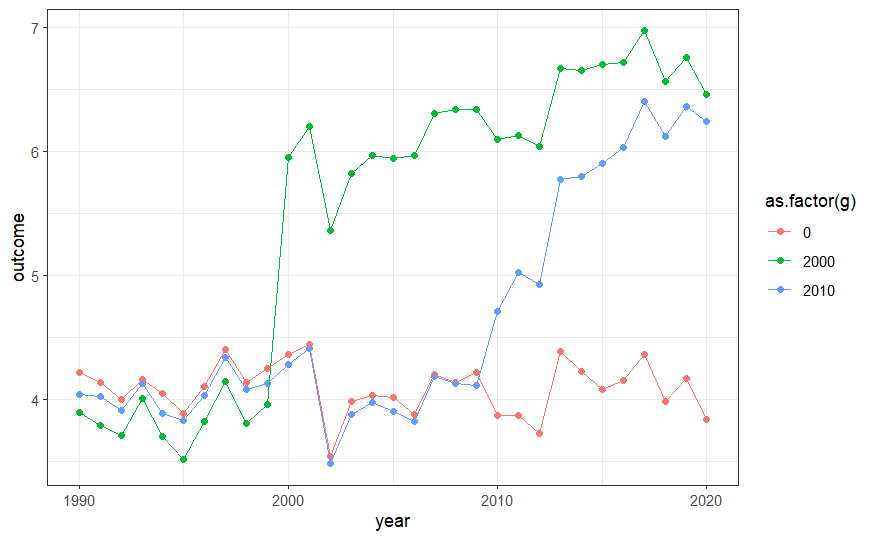

```r
df_het %>%
  group_by(year,g) %>%
  summarize(outcome = mean(dep_var)) %>%
  ungroup() %>%
  ggplot(aes(x=year,y=outcome,col=as.factor(g))) +
  geom_point() +
  geom_line() +
  theme_bw()
```

처리가 시작된 2000년과 2010년에 따라 기울기의 변화가 급격히 나타나는 것을 볼 수 있습니다.

### Estimate Two-stage Difference-in-Differences

#### Static DID

“정적 차이-차이 추정(static DiD estimation)”이란 변하지 않는 효과를 가진 차이-차이 모델을 추정하는 것입니다. 여기서 설명된 내용에 따르면, R의 `fixest` 패키지의 기능들을 활용해 이 과정을 수행할 수 있습니다. 여기서 몇 가지 중요한 포인트가 있습니다:

1. **고정 효과 명시**: `fixest::feols` 함수를 사용하면 `|` 기호를 이용해 고정 효과를 손쉽게 명시할 수 있습니다. 고정 효과는 시간이나 개체 등에 따른 변하지 않는 특성을 모델에서 통제하는 것을 말합니다.
2. **개선된 요인 변수 지원**: `fixest::i`는 범주형 변수를 더 잘 처리할 수 있도록 해주며, 이는 모델의 해석을 개선할 수 있습니다.
3. **`did2s` 함수와 `fixest` 객체**: `did2s` 함수를 사용해 추정하면, `fixest` 패키지의 추정 객체를 반환합니다. 이는 `fixest::esttable` (추정 결과를 표로 나타내기), `fixest::coefplot` (계수를 그래프로 나타내기), 그리고 `fixest::iplot` (상호작용 항을 포함한 모델의 결과를 그래프로 나타내기) 같은 `fixest` 패키지의 다른 함수들과 호환됩니다.

이를 통해, 고정 효과를 포함한 정적 DiD 모델을 추정하고, 이 결과를 다양한 방식으로 시각화하거나 표현할 수 있습니다. 이 모든 과정이 `fixest` 패키지 안에서 이루어지기 때문에, 분석 과정이 통합되고 효율적입니다.

```r
static = did2s(
  df_het, #data
  yname = 'dep_var',
  first_stage = ~ 0 | state + year,
  second_stage = ~ i(treat,ref=FALSE),
  treatment = 'treat',
  cluster_var = 'state'
)
```

```
Running Two-stage Difference-in-Differences
 - first stage formula `~ 0 | state + year`
 - second stage formula `~ i(treat, ref = FALSE)`
 - The indicator variable that denotes when treatment is on is `treat`
 - Standard errors will be clustered by `state`
```

결과를 봅시다.

```r
fixest::esttable(static)
```

```
                           static
Dependent Var.:           dep_var

treat = TRUE    2.152*** (0.0476)
_______________ _________________
S.E. type                  Custom
Observations               46,500
R2                        0.33790
Adj. R2                   0.33790
---
Signif. codes: 0 '***' 0.001 '**' 0.01 '*' 0.05 '.' 0.1 ' ' 1
```

추정 결과는 `fixest::esttable` 함수로 출력되며, ’treat = TRUE’의 계수는 처리 효과를 나타냅니다. 여기서 추정된 효과는 2.152로, 괄호 안의 숫자 0.0476은 계수의 표준 오차를 나타냅니다. 별표 세 개는 이 효과가 통계적으로 매우 유의미함을 나타냅니다(일반적으로 p-value가 0.001보다 작을 때 사용됩니다).

이 결과는 ‘treat’ 변수가 참일 때(즉, 처리가 적용되었을 때) 예상되는 종속 변수 ’dep_var’의 변화량이 약 2.152 단위라는 것을 보여주며, 이 변화량은 통계적으로 유의미한 것으로 나타났습니다. 이는 처리(예: 정책, 프로그램 등)가 긍정적인 영향을 미쳤음을 나타낼 수 있습니다.

### Event study

```r
es <- did2s(df_het,
            yname='dep_var',
            first_stage = ~0|state+year,
            second_stage = ~i(rel_year,ref=c(-1,Inf)),
            treatment = 'treat',
            cluster_var='state')
```

```
Running Two-stage Difference-in-Differences
 - first stage formula `~ 0 | state + year`
 - second stage formula `~ i(rel_year, ref = c(-1, Inf))`
 - The indicator variable that denotes when treatment is on is `treat`
 - Standard errors will be clustered by `state`
```

결과를 살펴보겠습니다.

```r
fixest::esttable(es)
```

```
                                es
Dependent Var.:            dep_var

rel_year = -20   -0.0793. (0.0461)
rel_year = -19    -0.0271 (0.0532)
rel_year = -18    -0.0272 (0.0486)
rel_year = -17    -0.0336 (0.0428)
rel_year = -16    -0.0558 (0.0529)
rel_year = -15     0.0168 (0.0507)
rel_year = -14    -0.0209 (0.0493)
rel_year = -13    -0.0222 (0.0398)
rel_year = -12     0.0054 (0.0457)
rel_year = -11    -0.0479 (0.0594)
rel_year = -10    -0.0325 (0.0341)
rel_year = -9     -0.0375 (0.0304)
rel_year = -8     -0.0309 (0.0321)
rel_year = -7     -0.0071 (0.0363)
rel_year = -6     -0.0396 (0.0272)
rel_year = -5   -0.0792** (0.0304)
rel_year = -4     -0.0342 (0.0280)
rel_year = -3     -0.0152 (0.0305)
rel_year = -2     -0.0387 (0.0323)
rel_year = 0     1.304*** (0.0561)
rel_year = 1     1.533*** (0.0644)
rel_year = 2     1.597*** (0.0567)
rel_year = 3     1.719*** (0.0606)
rel_year = 4     1.846*** (0.0477)
rel_year = 5     1.991*** (0.0563)
rel_year = 6     2.079*** (0.0643)
rel_year = 7     2.165*** (0.0585)
rel_year = 8     2.259*** (0.0580)
rel_year = 9     2.278*** (0.0533)
rel_year = 10    2.415*** (0.0601)
rel_year = 11    2.456*** (0.0819)
rel_year = 12    2.507*** (0.0797)
rel_year = 13    2.481*** (0.0846)
rel_year = 14    2.626*** (0.0697)
rel_year = 15    2.813*** (0.0827)
rel_year = 16    2.763*** (0.0824)
rel_year = 17    2.811*** (0.0794)
rel_year = 18    2.777*** (0.0818)
rel_year = 19    2.786*** (0.0902)
rel_year = 20    2.815*** (0.0830)
_______________ __________________
S.E. type                   Custom
Observations                46,500
R2                         0.36048
Adj. R2                    0.35994
---
Signif. codes: 0 '***' 0.001 '**' 0.01 '*' 0.05 '.' 0.1 ' ' 1
```

시각적으로 알아봅니다.

```r
fixest::iplot(es,
              main = "Event study: Staggered treatment",
              xlab = "Relative time to treatment",
              col = "steelblue",
              ref.line = -0.5)

# Add the (mean) true effects
true_effects = head(tapply((df_het$te + df_het$te_dynamic), df_het$rel_year, mean), -1)
points(-20:20, true_effects, pch = 20, col = "black")
```

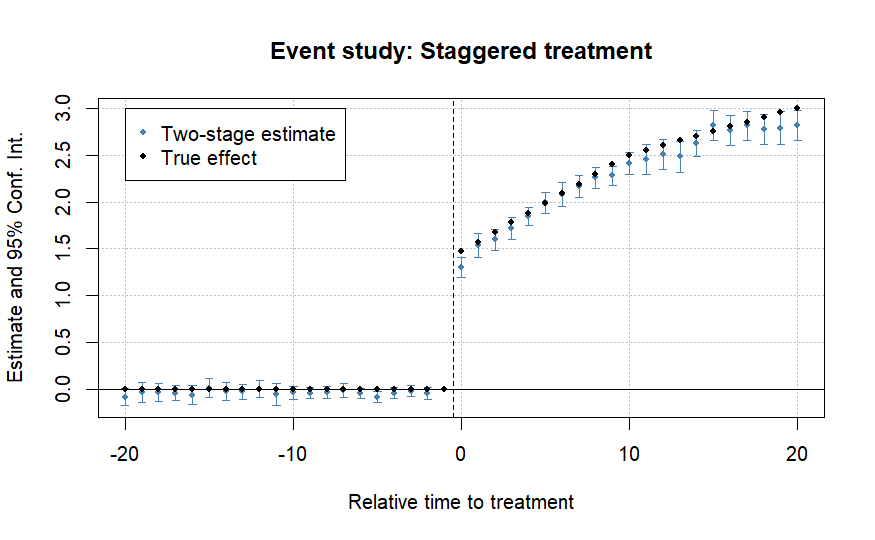

```r
# Legend
legend(x=-20, y=3, col = c("steelblue", "black"), pch = c(20, 20),
       legend = c("Two-stage estimate", "True effect"))
```

### 남은 것들

`Comparison to TWFE`를 생각해 봅시다. 2S-DID와 전통적인 TWFE 간의 모델 추정에 대해 이해하기로 합니다.

```r
twfe = feols(dep_var ~ i(rel_year, ref=c(-1, Inf)) | unit + year, data = df_het)
```

그리고 앞서 구한 결과와 비교합니다.

```r
fixest::iplot(list(es, twfe), sep = 0.2, ref.line = -0.5,
      col = c("steelblue", "#82b446"), pt.pch = c(20, 18),
      xlab = "Relative time to treatment",
      main = "Event study: Staggered treatment (comparison)")

points(-20:20, true_effects, pch = 21, col = "red")
```

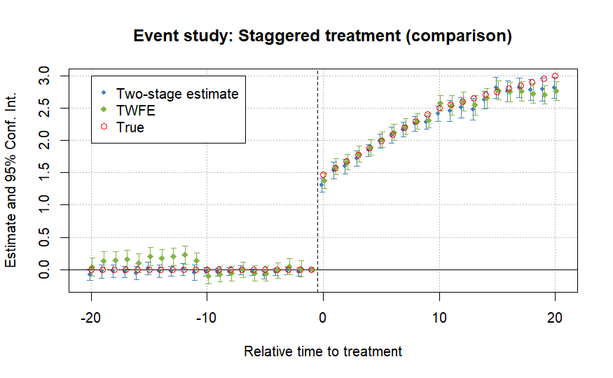

```r
# Legend
legend(x=-20, y=3, col = c("steelblue", "#82b446","red"), pch = c(20, 18,21),
       legend = c("Two-stage estimate", "TWFE","True"))
```

감사합니다.